# Cheese Succession (Brooke paper)

Collin Edwards

2021-08-26

# Setup

## libraries

```r
library(here)
library(tidyverse)
library(deSolve)
```

```r
library(ggplot2)
library(gridExtra)
library(cowplot)
library(viridis)
library(pander)
library(car)
```

## Functions

Sometimes it’s helpful to define a function for code we want to re-use a lot. The key function like that for me is something I call `gfig_saver`, which makes saving ggplot figures systematic.

```r
# function for saving ggplot figures and metadata. As fig_starter (which is for base graphics), except that saving ggfigures is inherently cleaner, as you are not feeding commands to an open graphics device

gfig_saver=function(gfig, #object to be saved
                    filename, #name of figure file to save as WITHOUT SUFFIX
                    description, #vector of strings, each will be put in its own line of meta file
                    ##  Note: generating file is defined in the function, date and time is automatically added.
                    ##default figure info:
                    width=12,
                    height=8,
                    res=300,
                    units="in",
                    figfold="5_figs" #folder to save figures in
){
  ## save meta file
  cat(c(description,
        "",##easy way to add an extra line to separate description for basic data.

        paste("from", knitr::current_input()),
        "RDS file with same name contains ggplot object used to generate this figure.",
        as.character(Sys.time())),
      sep="\n",
      file=here(figfold, paste0(filename,"_meta.txt", sep=""))
  )
  #save figure as jpg (change code here for other figure types)
  ggsave(filename=here(figfold, paste0(filename,".jpg")),
         plot=gfig,
         device="jpeg",
         dpi=res,
         width=width, height=height, units=units
  )
  ggsave(filename=here(figfold, paste0(filename,".pdf")),
         plot=gfig,
         device="pdf",
         dpi=res,
         width=width, height=height, units=units
  )
  #save ggplot object as RDS file, for easy manipulation later
  saveRDS(object = gfig, file=here(figfold, paste0(filename,".RDS")))
}
```

```r
theme.mine=theme(plot.title = element_text(face="bold", size=24),
                 text=element_text(size=rel(4.5)),
                 legend.text=element_text(size=rel(2))
)
```

## Purpose

The goal is to determine whether data from single-speceis and pairwise expeirments (e.g. at most pairwise interactions) in Brooke’s cheese data can explain the community dynamics from treatments innoculated with a full 7-species community. The manuscript for this project is [here](https://docs.google.com/document/u/1/d/1KIhnJMmHf3wOXv_0DQ9UgcjIVkz1v0FGFiyUVdktreE/edit?ts=608b2425).

## Plan

*Currently from email - reformat as necessary*

The goal:

Determine if the 7-species community can be predicted/described by pairwise interactions (we’re pretty sure it can’t, but it would be nice to say that for certain).

The problem(s):

“Community” is hard to define. With only 4 time points, classical population dynamics approaches are liable to run into issues. Estimating confidence intervals from the standard trajectory-matching approach for fitting population dynamics models is… hard? I don’t know how to do it, and would need to do a lot of digging.

The solution (I think):

If we imagine that the system is actually following Lotka-Volterra competition (the simplest competition model), then at least for the 2-species experiments, the populations will eventually reach an equilibrium (which can have one of the populations at size zero). The equilibrium for Lotka Volterra is clearly defined in terms of just carrying capacity and interaction terms (generally denoted with “alphas”) that capture either competition or stimulation. Using that knowledge, and assuming that the populations are at equilibrium on day 21, we can estimate the alphas and the carrying capacity from the paired experiments, and see if those predict the final population sizes of the 7-species community.

A little math background: The Lotka-Volterra competition model is defined by a system of Ordinary Differential Equations (ODEs). This is fancy math-speak for some equations that define how the size of the populations changes at any given point in time, based on the current size of the populations. For LV, it’s this set of equations:

x_1 = K_1 - alpha_21 * x_2

(and the other version, where each number is swapped)

And that’s kind of dry looking, but it’s just a different version of

y = mx + b.

where y and x are the sizes of our two populations (e.g. the things we have data for)

Taking this approach, we can find carrying capacity and interaction terms with linear regression using the single-species and pairwise interaction data (!!). We still face the caveats of our various assumptions (below), but this is suddenly incredibly tractable. And the question of “What would the 7-species community look like if it were mostly the result of pairwise interactions” could, I think, be addressed pretty easily at that point. The 7-species version of lotka volterra has more equations, but the equilibrium has the same structure, I believe, except it’s

K_1 - (sum of all six appropriate alpha * x terms).

(I’ll double check that at some point here). So we can use our fitted versions of all our K and alpha values from the pairwise and single-species experiments, plug them into the equation for equilibrium of the 7-species model, and predict what we would expect the 7-species equilibrium would be (assuming only pairwise interactions mattered). To look at if reality is significantly different from what we predict, we can use parametric bootstrapping: basically we generate “random” K and alpha values based on our estimated distributions from fitting those parameters from the single-species and pairwise experiments, and for each set of random K and alpha values, we make a prediction for the final community. We can do that a bunch of times, and that creates a distribution of expectations assuming pairwise interactions - if the real data is outside of 95% of that, then it’s significantly different. Since in this case we have 7 abundances that are not independent, we may need to use something like PERMANOVA to compare the bootstrap-simulated final communities with the actual 7-species community data, but that shouldn’t actually be very hard.

Some caveats: First, we’re assuming that lotka volterra dynamics do a good job of capturing the key dynamics in the system. Second, we’re assuming that populations are at equilibrium on day 21 – from the data, it looks like they are in some cases, and not in others. Additionally, communities of more than 2 species with lotka volterra competition aren’t guaranteed to have an equilibrium at all - they can exhibit non-equilibrium dynamics like periodic cycles through time, or mathematical chaos.

So I would go forward with this as described above, so long as we’re clear about what we’re doing in the text (happy to help make the writing clear on that). I think once I’ve at least prototyped this, I might also run it by a few more senior theoretical ecologists I work with, in case I’m missing some subtle issue.

One thing to bear in mind is that LV is also often unsuited to capturing mutualisms – there are some parameter values where both species explode to infinite size even though there’s a finite carrying capacity. I don’t think that’s an issue with our data, but it’s something to be aware of. I haven’t dug into it a ton, but there has been recent work on how to model community dynamics and coexistence when working with mutualisms. I might need to take a look at that at some point (although again, I think we have a good plan outlined above).

Some anti-caveats

One of the nice things about only working with the stable equilibrium (aside from the math being tractable) is that we’re not actually making any assumptions about growth rate or dynamics up to that point. We’re just assuming that each species has an equilibrium size that is a linear function of the other species at equilibrium. So if we wanted to, we could actually NOT call this lotka volterra, since our approach encompasses ANY model with that equilibrium conditions, not just lotka volterra. (But I think we still couch it in terms of LV, because folks are familiar with that).

A few pieces I may need to explore: We’re using some of the data to estimate different parameters in independent analyses, and it’s not quite clear to me how we account for that when representing error (e.g. our estimate of alpha_21 and alpha_12 come from fitting the same data of pairwise species competition, but we’re fitting that data in two different equations). I may need to think some more and/or consult Elizabeth. Additionally, there’s a generalized Lotka Volterra model that I’m not super familiar with, but appears to be more common for working with many-species communities. I believe that it is fundamentally the same thing as I’ve outlined above, but the formulation is different (e.g. different parameter names, somewhat different version of the equation), and it might be good to rework my math to match that nomenclature. I might dig into it.

The plan: I try this out with the data - fit the carrying capacities and the alphas with linear regression, see how well it predicts the data that I’m using to fit it, see how it predicts the 7-species community. I expect this will take a day or less of time, and I should be able to fit that in in the next two weeks. This won’t focus on significance testing, but just “can we estimate parameters” and “what do our estimated parameters suggest”. I write up a brief description of the methodology with code and example figures, and run it by Elizabeth Crone (statistical ecologist who can make suggestions on the non-independence of the different regressions), and then Steve Ellner, Sebastian Schrieber, and/or Giles Hooker, who have expertise in working with dynamical models (and in Giles’ case, literally wrote the book for fitting dynamical models to data) and can act as an additional sounding board for the “let’s assume we’re at equilibrium” bit. ??? Profit.

## Read in data

```r
dat.orig = raw = read.csv(here("1_raw_data",
                               "2018_08_21_Bayley_allPW.csv"))
```

# Approach 2: fit linear models

The underlying idea is that if we assume the communities are at equilibrium on day 21, if their dynamics are defined by lotka volterra dynamics, their abundance is a linear function of competitors. For the two-species LV model, the equilibrium densities of species 1 and species 2 (denoted $N_1^*$ and $N_2^*$) are defined by

$$N_1^* = K_1 - \alpha_{12}N_2^*$$

Since we’re assuming the populations are at equilibrium, we know $N_1^*$ and $N_2^*$, and we can just fit a regression model to estimate $K$ and $\alpha$. (and we can use the regression framework to estimate our error)

Using our pairwise experiments, we can estimate all parameters for species 1 simultaneously, with

$$N_1^* = K_1 - \alpha_{12}N_2^* - \alpha_{12}N_2^*-\dots$$

Note that when fitting the above model, for any given entry, only 0 or 1 of the Ns on the right hand side will be non-zero (that is, either the observation comes from a species alone, in which case all other Ns are 0, or it comes from a two-species experiment, in which case ONE other N will be some postitive number, and the rest will be zeros).

Using this framework, we can fit the data and see how well it predicts the observed 7-species community.

Note two caveats:

- if it doesn’t fit the 7-species data well, that suggests either complex interactions OR that one or more of the data sets isn’t at equilibrium.
- The error structure is probably pretty complicated, since we’re “re-using” the same data to estimate the parameters for multiple species. I may need to pick Elizabeth’s brain on this.

Potential exciting followup: Does this approach, as fit to high pH, do a better job predicting the data? This would suggest that the non-pairwise-effects are mediated by pH!

Update (8/26/21): fitting the data in two step process: first estimate k, then calculate everything else. So estimate k using original data, then for interaction terms fit a no-intercept model after subtracting the carrying capacity.

## Step 1: restructure data

We need a data frame with a row for each experiment, and a column for the density of each species.

```r
#make empty data frame
#We want to store cfus for each species,
df.template =
  dat.mat = setNames(data.frame(matrix(ncol = 2*length(unique(raw$spec))+2, nrow = 0)),
                     c(as.character(unique(raw$spec)), "cond", "rep",paste0("pres.",c(as.character(unique(raw$spec)))))
  )
raw.use = raw %>%
  filter(day == 21) %>%
  filter(pH == 5)
#handle the alones
for(cur.spec in unique(raw.use$spec)){
  print(cur.spec)
  dat.cur = raw.use %>%
    filter(spec == cur.spec) %>%
    filter(cond == "alone")
  df.fill=as.data.frame(matrix(0,
                               nrow=nrow(dat.cur),
                               ncol=ncol(dat.mat)))
  names(df.fill) = names(dat.mat)
  df.fill[,cur.spec]=dat.cur$cfus
  df.fill[,"rep"]=dat.cur$rep
  df.fill[,"cond"]="alone"
  df.fill[,paste0("pres.",cur.spec)] = T
  dat.mat = rbind(dat.mat, df.fill)
}
```

```
## [1] "BC9"
## [1] "BC10"
## [1] "JB5"
## [1] "JB7"
## [1] "135E"
## [1] "JBC"
## [1] "JB370"
```

```r
## pairs
spec.vec = as.character(unique(raw.use$spec))

for(i.spec in 1:(length(spec.vec)-1)){
  cur.spec = spec.vec[i.spec]
  for(j.spec in (i.spec+1):length(spec.vec)){
    other.spec = spec.vec[j.spec]
    #get cfus of current species
    dat.cur = raw.use %>%
      filter(spec == cur.spec) %>%
      filter(cond == other.spec)
    #get cfus of other species
    dat.other = raw.use %>%
      filter(spec == other.spec) %>%
      filter(cond == cur.spec)
    #handle replicate mismatching
    dat.cur = dat.cur[dat.cur$rep %in% dat.other$rep,]
    dat.other = dat.other[dat.other$rep %in% dat.cur$rep,]
    dat.cur=dat.cur[order(dat.cur$rep),]
    dat.other=dat.other[order(dat.other$rep),]

    ## The following code is a bunch of sanity checking.
    if(nrow(dat.cur) != nrow(dat.other)){
      stop("dimensions not matching up. investigate")
      # print(paste(cur.spec, other.spec))
      # print("dimensions not matching up. investigate")
    }
    if(any(dat.cur$rep != dat.other$rep)){
      stop("replicates not matching up. investigate")
      # print(paste(cur.spec, other.spec))
      # print("replicates not matching up. investigate")
    }
    df.fill=as.data.frame(matrix(0,
                                 nrow=nrow(dat.cur),
                                 ncol=ncol(dat.mat)))
    names(df.fill) = names(dat.mat)
    df.fill[ , cur.spec] = dat.cur$cfus
    df.fill[ , other.spec] = dat.other$cfus
    df.fill[,"rep"]=dat.cur$rep
    df.fill[,"cond"]="paired-comp"
    df.fill[,paste0("pres.",cur.spec)] = T
    df.fill[,paste0("pres.",other.spec)] = T
    dat.mat = rbind(dat.mat, df.fill)
  }
}
dat.mat$day = 21
dat.mat$pH = 5
names(dat.mat)[names(dat.mat)=="pres.135E"]="pres.X135E"

write.csv(dat.mat,
          file = here("2_data_wrangling","matrix-form.csv"),
          row.names = FALSE
)
```

## Fit at once

### Testing: fit one species

```r
library(lme4)
dat.fit = read.csv(file = here("2_data_wrangling","matrix-form.csv"))
#NOTE: R adds a leading X to column names that start with numbers

dat.k = dat.orig %>%
  filter(day==21) %>%
  filter(spec=="BC9") %>%
  filter(cond=="alone") %>%
  filter(pH == 5)
out = lm(cfus ~ 1, data = dat.k )
k.cur = out$coefficients[[1]]
dat.mod = dat.fit[dat.fit$pres.BC9==1,]
dat.mod$BC9=dat.mod$BC9-k.cur
out = lm(BC9 ~ -1 + BC10 + JB5 + JB7 + X135E + JBC + JB370,
         data = dat.mod)
summary(out)
```

```
##
## Call:
## lm(formula = BC9 ~ -1 + BC10 + JB5 + JB7 + X135E + JBC + JB370,
##     data = dat.mod)
##
## Residuals:
##        Min         1Q     Median         3Q        Max
## -237586019  -14199353   -1060000   14414118  330351390
##
## Coefficients:
##         Estimate Std. Error t value Pr(>|t|)
## BC10   2.209e-02  3.607e-01   0.061 0.951658
## JB5    5.778e+03  4.211e+04   0.137 0.891965
## JB7    4.759e+04  6.769e+05   0.070 0.944510
## X135E  4.997e+00  1.107e+00   4.516 0.000131 ***
## JBC   -2.143e-02  6.839e-01  -0.031 0.975256
## JB370  2.661e+01  3.578e+00   7.438 8.64e-08 ***
## ---
## Signif. codes:  0 '***' 0.001 '**' 0.01 '*' 0.05 '.' 0.1 ' ' 1
##
## Residual standard error: 96680000 on 25 degrees of freedom
## Multiple R-squared:  0.7519, Adjusted R-squared:  0.6923
## F-statistic: 12.62 on 6 and 25 DF,  p-value: 1.578e-06
```

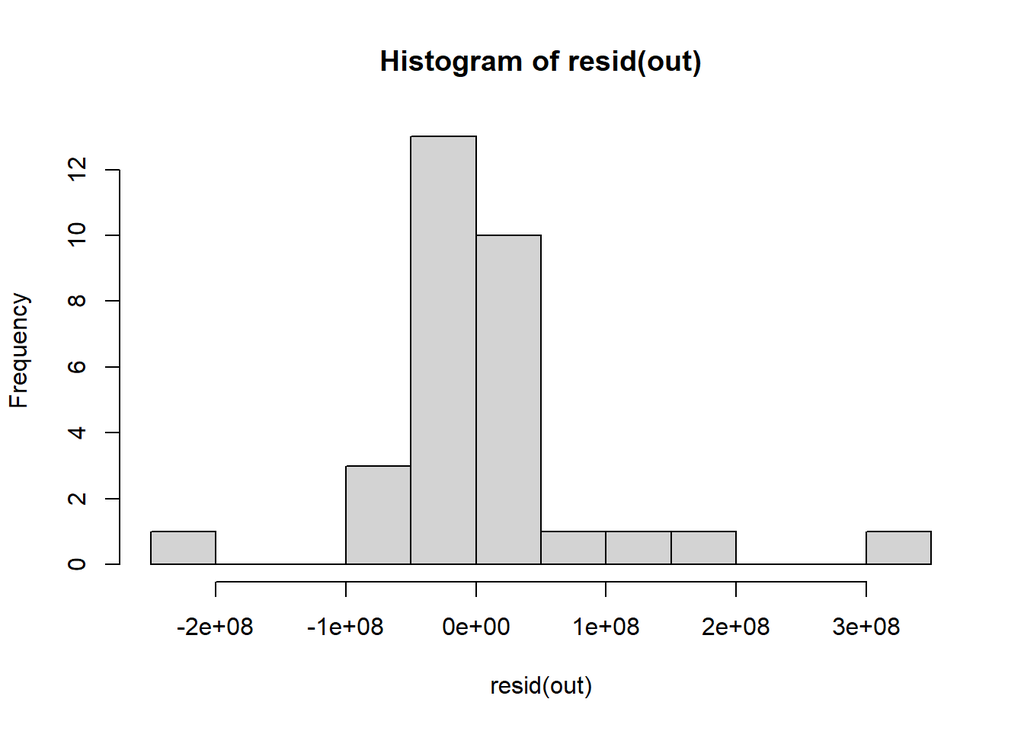

```r
hist(resid(out), breaks=20)
```

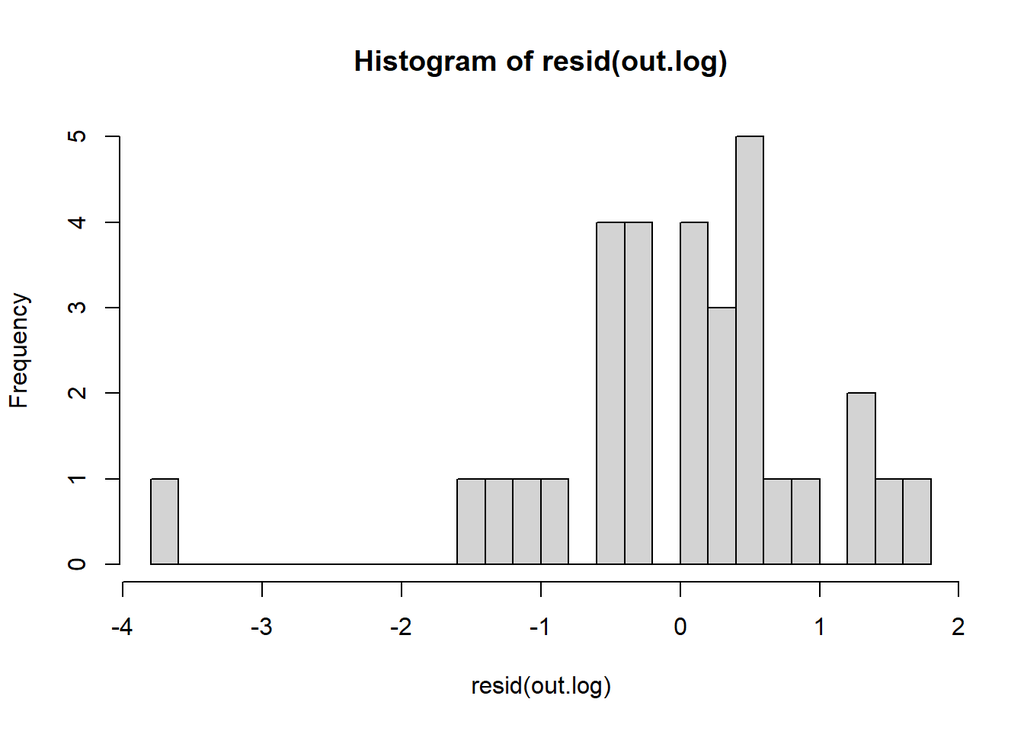

```r
# coefficients(out)

dat.log=dat.fit
dat.log[,1:7] = log(dat.log[,1:7]+1)
#let's try a log transform, because that seems relevant
out.log = lm(BC9 ~ BC10 + JB5 + JB7 + X135E + JBC + JB370,
             data = dat.log[dat.log$pres.BC9==1,])
hist(resid(out.log), breaks=20)
```

```r
#Both seem okay, linear scale seems a bit better. For simplicity, I'm going to stick with non-log transformed for now. It should be reasonably easy to update this later.
```

```r
out.pois = glm(BC9 ~ BC10 + JB5 + JB7 + X135E + JBC + JB370,
               data = dat.fit[dat.fit$pres.BC9==1,], family="poisson")
AIC(out, out.pois)
```

```
##          df          AIC
## out       7 1.235293e+03
## out.pois  7 1.860003e+09
```

```r
# library(MASS)
# out.nb = glm.nb(BC9 ~ BC10 + JB5 + JB7 + X135E + JBC + JB370,
#          data = dat.fit[dat.fit$pres.BC9==1,])
# AIC(out, out.nb)
```

#### Poisson or normal?

```r
aic.comp = data.frame(species = spec.vec,
                      aic.norm = rep(-999, length(spec.vec)),
                      aic.pois = rep(-999, length(spec.vec))
)
specvec.fit=spec.vec
specvec.fit[specvec.fit=="135E"] = "X135E"
for(i.spec in 1:length(spec.vec)){
  cur.spec = specvec.fit[i.spec]
  print(cur.spec)
  #generate formula automatically
  form = paste0(cur.spec," ~ ", paste(specvec.fit[-i.spec], collapse = " + "))
  ind.use = dat.fit[,paste0("pres.",cur.spec)]==1
  dat.cur = dat.fit[ind.use,]
  out.cur = lm(formula(form),
               data = dat.cur)
  aic.comp$aic.norm[i.spec]=AIC(out.cur)
  out.pois = glm(formula(form),
                 data = dat.cur, family = "poisson")
  aic.comp$aic.pois[i.spec]=AIC(out.pois)
}
```

```
## [1] "BC9"
## [1] "BC10"
## [1] "JB5"
```

```
## [1] "JB7"
```

```
## [1] "X135E"
```

```
## [1] "JBC"
## [1] "JB370"
```

Comparing AICs, it’s clear that normally distributed error is far better than poisson distributed.

```r
pander(aic.comp)
```

| species | aic.norm | aic.pois |
| --- | --- | --- |
| BC9 | 1236 | 1.86e+09 |
| BC10 | 1119 | 553097506 |
| JB5 | 1330 | 1.788e+10 |
| JB7 | 1352 | 5.852e+09 |
| 135E | 1158 | 63098226 |
| JBC | 1140 | 323786401 |
| JB370 | 1034 | 40137589 |

### Loop over all species

```r
res.est = NULL
spec.vecfit = unique(raw$spec)
spec.vecfit[spec.vecfit=="135E"] = "X135E"
for(i.spec in 1:length(spec.vec)){
  cur.spec = spec.vecfit[i.spec]
  print(cur.spec)

  ## calculate K
  dat.k = dat.orig
  dat.k$spec[dat.k$spec=="135E"]="X135E"
  dat.k = dat.k %>%
    filter(day==21) %>%
    filter(spec==cur.spec) %>%
    filter(cond=="alone") %>%
    filter(pH == 5)
  out.k = lm(cfus ~ 1, data = dat.k )
  k.cur = out$coefficients[[1]]
  ## modify the data to ensure we're accounting for k
  ind.use = dat.fit[,paste0("pres.",cur.spec)]==1
  dat.cur = dat.fit[ind.use,]
  dat.cur[,cur.spec]=dat.cur[,cur.spec]-k.cur
  #generate formula automatically
  #
  #
  form = paste0(cur.spec," ~ -1 + ", paste(spec.vecfit[-i.spec], collapse = " + "))
  out.cur = lm(formula(form),
               data = dat.cur)
  cur.df = data.frame(est = c(coefficients(out.k),coefficients(out.cur)),
                      se = c(coef(summary(out.k))[,2], coef(summary(out.cur))[,2]))
  #switch to alphas (for everything but Ks, which are the first entry) by multiplying by -1
  cur.df$est[-1]=-cur.df$est[-1]
  cur.df$spec = cur.spec
  cur.df$name = rownames(cur.df)
  cur.df$pH = 5
  rownames(cur.df)=NULL
  cur.df$name[1] = "K"
  #reorder
  cur.df=cur.df[,c("spec","name","est","se", "pH")]
  res.est = rbind(res.est, cur.df)
}
```

```
## [1] "BC9"
## [1] "BC10"
## [1] "JB5"
## [1] "JB7"
## [1] "X135E"
## [1] "JBC"
## [1] "JB370"
```

```r
## and that's our fits
##
write.csv(res.est,
          file = here("4_res",
                      "coefficient-estimates-pH5.csv"),
          row.names = FALSE
)
## write metadata
cat("meta-data for coefficeint-estimates.csv",
    file = here("4_res", "coefficient-estimates-metadata.txt"),
    sep = "\n")
cat(c("Fitting Lotka-Volterra coefficients K and alpha through linear regression (assuming day 21 populations are at equilibrium",
      "We assume the error is normally distributed - this seems close enough to true.",
      "",
      "spec is the focal species",
      "name is the coefficient name. In the cases where name is a species name, it's an alpha term, and the species named is the competing species",
      "est is the estimate FOR LOTKA VOLTERRA MODEL. So the K is in units of individuals, and the other terms are the ALPHAs, which are the coefficient estimates times negative 1.",
      "se is the standard error from the lienar regression"),
    file = here("4_res", "coefficient-estimates-pH5-metadata.txt"),
    sep = "\n",
    append=T)
```

## Comparing to community data

### restructure data

```r
raw.com = raw %>%
  filter(cond == "community") %>%
  filter(day == 21) %>%
  filter(pH == 5)

nrep = max(raw.com$rep)
dat.com = data.frame(BC9 = rep(-99, nrep),
                     BC10 = rep(-99, nrep),
                     JB5 = rep(-99, nrep),
                     JB7 = rep(-99, nrep),
                     X135E = rep(-99, nrep),
                     JBC = rep(-99, nrep),
                     JB370 = rep(-99, nrep),
                     rep = 1:nrep
)


## pairs
raw.com$spec[raw.com$spec=="135E"] = "X135E"
spec.vec = as.character(unique(raw.com$spec))

for(cur.spec in spec.vec){
  #get cfus of current species
  dat.cur = raw.com %>%
    filter(spec == cur.spec)
  dat.com[dat.cur$rep,cur.spec] = dat.cur$cfus
}
## add NAs
dat.com[dat.com==-99]=NA


write.csv(dat.com,
          file = here("2_data_wrangling","matrix-form-comdat.csv"),
          row.names = FALSE
)
```

### predicting

```r
dat.fit = read.csv(file = here("2_data_wrangling","matrix-form.csv"))
dat.com = na.omit(dat.com)
dat.pred = dat.com
dat.pred[,-which(names(dat.com)=="rep")]=0
dat.pred.pois = dat.pred
dat.pred.long = NULL
dat.pred.long.pois = NULL
for(i.spec in 1:(length(spec.vec))){
  print(cur.spec)
  cur.spec = spec.vecfit[i.spec]
  #generate formula automatically
  form = paste0(cur.spec," ~ ", paste(spec.vecfit[-i.spec], collapse = " + "))
  ind.use = dat.fit[,paste0("pres.",cur.spec)]==1
  dat.cur = dat.fit[ind.use,]
  out.cur = lm(formula(form),
               data = dat.cur)
  dat.pred[,cur.spec] = predict(out.cur, newdata = dat.com)
  #with CIs, for dat.pred.long
  cur.df = as.data.frame(predict(out.cur, newdata = dat.com, interval = "confidence"))
  cur.df$replicate=dat.com$rep
  cur.df$spec = cur.spec
  cur.df$fam="normal"
  cur.df$within = dat.com[,cur.spec] > cur.df[, "lwr"] &
    dat.com[, cur.spec] < cur.df[, "upr"]
  dat.pred.long = rbind(dat.pred.long, cur.df)
  ## Now for poisson
  out.cur = glm(formula(form),
                data = dat.cur,
                family="poisson")
  dat.pred.pois[,cur.spec] = predict(out.cur, newdata = dat.com, type="response")
  # with CIs, for dat.pred.long
  cur.df = as.data.frame(predict(out.cur, newdata = dat.com, se.fit=TRUE, type="response"))
  cur.df$replicate=dat.com$rep
  cur.df$spec = cur.spec
  cur.df$fam="pois"
  dat.pred.long.pois = rbind(dat.pred.long.pois, cur.df)
}
```

```
## [1] "JB370"
## [1] "BC9"
## [1] "BC10"
```

```
## [1] "JB5"
```

```
## [1] "JB7"
```

```
## [1] "X135E"
## [1] "JBC"
```

```r
dat.pred.long.pois$ph = 5

write.csv(dat.pred.long,
          here("4_res","predictions-from-pH5.csv"),
          row.names=F
)
write.csv(dat.pred.long,
          here("4_res","predictions-from-pH5-poisson.csv"),
          row.names=F
)
```

So our predicted community not only doesn’t match our actual community very well, it also doesn’t really match possible realities very well. We have a lot of negative numbers.

```r
pander(dat.pred)
```

Table continues below

|  | BC9 | BC10 | JB5 | JB7 | X135E |
| --- | --- | --- | --- | --- | --- |
| **1** | -1.956e+11 | 35186936 | -1.442e+11 | 367095448 | 16066730 |
| **2** | -3.506e+11 | 8178262 | -3.468e+11 | 210152660 | 12736532 |
| **4** | -1.715e+12 | 956073 | -1.677e+12 | 218210598 | 11649550 |
| **5** | -1.303e+13 | 42672964 | -1.296e+13 | 322148995 | 15916095 |

|  | JBC | JB370 | rep |
| --- | --- | --- | --- |
| **1** | -5.14e+09 | 654888 | 1 |
| **2** | -319783466 | -2441776 | 2 |
| **4** | -3.851e+09 | -3180642 | 4 |
| **5** | -7.852e+09 | 1814614 | 5 |

### Visualizing

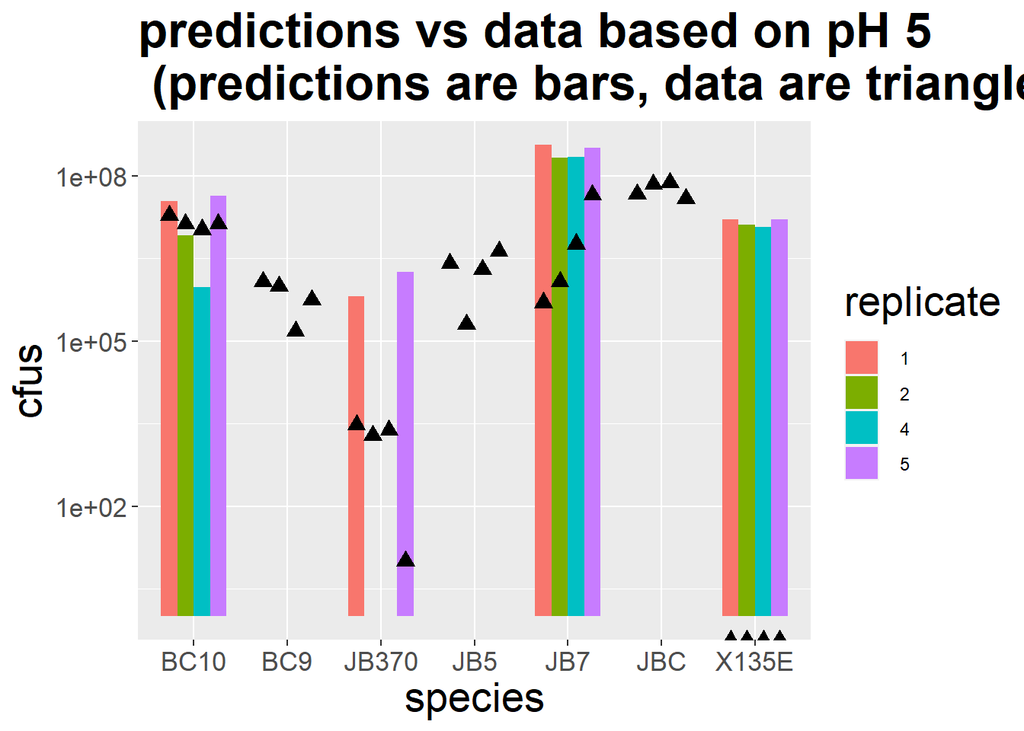

```r
dat.pred.long$replicate = as.character(dat.pred.long$replicate)
dat.pred.long.pois$replicate = as.character(dat.pred.long.pois$replicate)
dat.pred.long.pois$fit = dat.pred.long.pois$fit + 1
dat.com.long = dat.com %>%
  pivot_longer(cols = !matches("rep"),
               names_to = "spec") %>%
  rename(fit = value)

ggplot(data = dat.pred.long, aes(x = spec, y = fit))+
  geom_col(aes(fill=replicate),
           position = position_dodge(.7),
           width=.7)+
  geom_point(data = dat.com.long, shape=17,
             position = position_dodge(.7),
             aes(group = rep),
             size=3)+
  xlab("species")+
  ylab("cfus")+
  ggtitle("predictions vs data based on pH 5\n (predictions are bars, data are triangles)")+
  theme.mine+
  scale_y_log10()
```

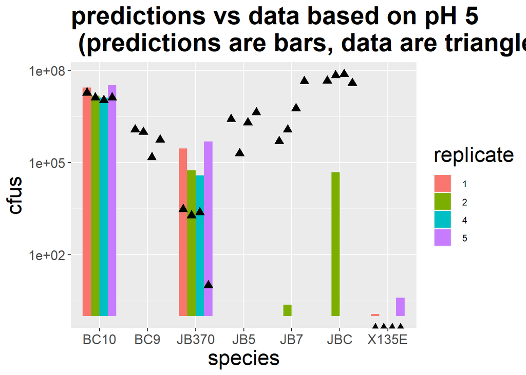

```r
ggplot(data = dat.pred.long.pois, aes(x = spec, y = fit))+
  geom_col(aes(fill=replicate),
           position = position_dodge(.7),
           width=.7)+
  geom_point(data = dat.com.long, shape=17,
             position = position_dodge(.7),
             aes(group = rep),
             size=3)+
  xlab("species")+
  ylab("cfus")+
  ggtitle("predictions vs data based on pH 5\n (predictions are bars, data are triangles)")+
  theme.mine+
  scale_y_log10()
```

# pH 7

Now that we can fit Lotka Volterra with regression models, let’s try again, but with pH 7.

## quick sanity check for ks

```r
dat.orig %>%
  filter(cond == "alone") %>%
  filter(day == 21) %>%
  filter(pH == 5 ) %>%
  # View() %>%
  group_by(spec) %>%
  summarize(cfus = median(cfus))
```

```
## # A tibble: 7 x 2
##   spec      cfus
##   <chr>    <dbl>
## 1 135E  22400000
## 2 BC10  77500000
## 3 BC9   16700000
## 4 JB370  7900000
## 5 JB5     170000
## 6 JB7        120
## 7 JBC   70000000
```

## Restructuring the data

```r
#make empty data frame
#We want to store cfus for each species,
dat.mat7 = setNames(data.frame(matrix(ncol = 2*length(unique(raw$spec))+2, nrow = 0)),
                    c(as.character(unique(raw$spec)), "cond", "rep",paste0("pres.",c(as.character(unique(raw$spec)))))
)
raw.use = raw %>%
  filter(day == 21) %>%
  filter(pH == 7)
#handle the alones
for(cur.spec in unique(raw.use$spec)){
  print(cur.spec)
  dat.cur = raw.use %>%
    filter(spec == cur.spec) %>%
    filter(cond == "alone")
  df.fill=as.data.frame(matrix(0,
                               nrow=nrow(dat.cur),
                               ncol=ncol(dat.mat7)))
  names(df.fill) = names(dat.mat7)
  df.fill[,cur.spec]=dat.cur$cfus
  df.fill[,"rep"]=dat.cur$rep
  df.fill[,"cond"]="alone"
  df.fill[,paste0("pres.",cur.spec)] = T
  dat.mat7 = rbind(dat.mat7, df.fill)
}
```

```
## [1] "BC9"
## [1] "BC10"
## [1] "JB5"
## [1] "JB7"
## [1] "135E"
## [1] "JBC"
## [1] "JB370"
```

```r
## pairs
spec.vec = as.character(unique(raw.use$spec))

for(i.spec in 1:(length(spec.vec)-1)){
  cur.spec = spec.vec[i.spec]
  for(j.spec in (i.spec+1):length(spec.vec)){
    other.spec = spec.vec[j.spec]
    #get cfus of current species
    dat.cur = raw.use %>%
      filter(spec == cur.spec) %>%
      filter(cond == other.spec)
    #get cfus of other species
    dat.other = raw.use %>%
      filter(spec == other.spec) %>%
      filter(cond == cur.spec)
    #handle replicate mismatching
    dat.cur = dat.cur[dat.cur$rep %in% dat.other$rep,]
    dat.other = dat.other[dat.other$rep %in% dat.cur$rep,]
    dat.cur=dat.cur[order(dat.cur$rep),]
    dat.other=dat.other[order(dat.other$rep),]

    ## The following code is a bunch of sanity checking.
    if(nrow(dat.cur) != nrow(dat.other)){
      stop("dimensions not matching up. investigate")
      # print(paste(cur.spec, other.spec))
      # print("dimensions not matching up. investigate")
    }
    if(any(dat.cur$rep != dat.other$rep)){
      stop("replicates not matching up. investigate")
      # print(paste(cur.spec, other.spec))
      # print("replicates not matching up. investigate")
    }
    df.fill=as.data.frame(matrix(0,
                                 nrow=nrow(dat.cur),
                                 ncol=ncol(dat.mat7)))
    names(df.fill) = names(dat.mat7)
    df.fill[ , cur.spec] = dat.cur$cfus
    df.fill[ , other.spec] = dat.other$cfus
    df.fill[,"rep"]=dat.cur$rep
    df.fill[,"cond"]="paired-comp"
    df.fill[,paste0("pres.",cur.spec)] = T
    df.fill[,paste0("pres.",other.spec)] = T
    dat.mat7 = rbind(dat.mat7, df.fill)
  }
}
dat.mat7$day = 21
dat.mat7$pH = 7
names(dat.mat7)[names(dat.mat7)=="pres.135E"]="pres.X135E"

write.csv(dat.mat7,
          file = here("2_data_wrangling","matrix-form-pH7.csv"),
          row.names = FALSE
)
```

### Loop over all species

```r
dat.fit = read.csv(file = here("2_data_wrangling","matrix-form-pH7.csv"))
res.est = NULL
spec.vecfit = unique(raw$spec)
spec.vecfit[spec.vecfit=="135E"] = "X135E"
for(i.spec in 1:length(spec.vec)){
  cur.spec = spec.vecfit[i.spec]
  print(cur.spec)

  ## calculate K
  dat.k = dat.orig
  dat.k$spec[dat.k$spec=="135E"]="X135E"
  dat.k = dat.k %>%
    filter(day==21) %>%
    filter(spec==cur.spec) %>%
    filter(cond=="alone") %>%
    filter(pH == 7)
  out.k = lm(cfus ~ 1, data = dat.k )
  k.cur = out$coefficients[[1]]
  ## modify the data to ensure we're accounting for k
  ind.use = dat.fit[,paste0("pres.",cur.spec)]==1
  dat.cur = dat.fit[ind.use,]
  dat.cur[,cur.spec]=dat.cur[,cur.spec]-k.cur
  #generate formula automatically
  #
  #
  form = paste0(cur.spec," ~ -1 + ", paste(spec.vecfit[-i.spec], collapse = " + "))
  out.cur = lm(formula(form),
               data = dat.cur)
  est = coefficients(out.cur)
  #sometimes we're getting NAs for se
  #and this doesn't even show up in coef(summary())
  # so we have to do something a little fiddly.
  se = est*NA
  coef.temp = coef(summary(out.cur))[,2]
  se[names(coef.temp)] = coef.temp
  cur.df = data.frame(est = c(coefficients(out.k), est),
                      se = c(coef(summary(out.k))[,2],se))
  #switch to alphas (for everything but Ks, which are the first entry) by multiplying by -1
  cur.df$est[-1]=-cur.df$est[-1]
  cur.df$spec = cur.spec
  cur.df$name = rownames(cur.df)
  cur.df$pH = 7
  rownames(cur.df)=NULL
  cur.df$name[1] = "K"
  #reorder
  cur.df=cur.df[,c("spec","name","est","se", "pH")]
  res.est = rbind(res.est, cur.df)
}
```

```
## [1] "BC9"
## [1] "BC10"
## [1] "JB5"
## [1] "JB7"
## [1] "X135E"
## [1] "JBC"
## [1] "JB370"
```

```r
write.csv(res.est,
          file = here("4_res",
                      "coefficient-estimates-pH7.csv"),
          row.names = FALSE
)
## write metadata
cat("meta-data for coefficeint-estimates.csv",
    file = here("4_res", "coefficient-estimates-pH7-metadata.txt"),
    sep = "\n")
cat(c("Fitting Lotka-Volterra coefficients K and alpha through linear regression (assuming day 21 populations are at equilibrium",
      "As before, but now we are doing pH7 data",
      "We assume the error is normally distributed - this seems close enough to true.",
      "",
      "spec is the focal species",
      "name is the coefficient name. In the cases where name is a species name, it's an alpha term, and the species named is the competing species",
      "est is the estimate FOR LOTKA VOLTERRA MODEL. So the K is in units of individuals, and the other terms are the ALPHAs, which are the coefficient estimates times negative 1.",
      "se is the standard error from the lienar regression"),
    file = here("4_res", "coefficient-estimates-pH7-metadata.txt"),
    sep = "\n",
    append=T)
```

### Comparing k estimates

Here we look at how the estimates of K differ between Approach 1 and Approach 2.

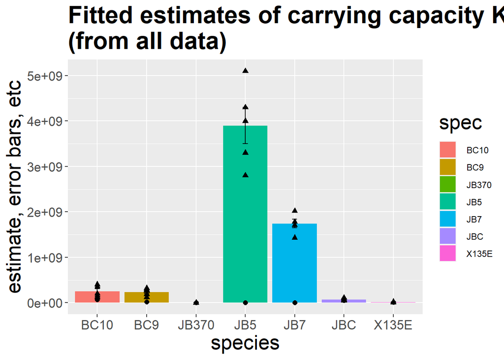

```r
#read in trajectory-based estimates
dat.traj = read.csv(file=here("4_res","logistic-loop-fits.csv"))
dat.traj$spec[dat.traj$spec=="135E"] = "X135E"

#grab the k-relevant data from our regression approach
k.lm = res.est %>%
  filter(name=="K")

#Let's extract the "alone" data from dat.mat
dat.alone  = raw %>%
  filter(pH == 7) %>%
  filter(day == 21) %>%
  filter(cond == "alone")
dat.alone$spec[dat.alone$spec=="135E"]="X135E"

ggplot(k.lm, aes(x=spec, y = est))+
  geom_col(aes(fill = spec))+
  geom_errorbar(aes(x =spec,
                    ymin=est-se,
                    ymax=est+se),
                width = .1
  )+
  geom_point(data = dat.traj,
             aes(x = spec,
                 y = k), size=2)+
  geom_point(data = dat.alone,
             aes(x = spec, y = cfus),
             size = 2, shape = 17)+
  ggtitle("Fitted estimates of carrying capacity K\n(from all data)")+
  xlab("species")+
  ylab("estimate, error bars, etc")+
  theme.mine
```

## Comparing to community data

### restructure data

We did this the first time around. We can just read in dat.com

```r
dat.com = read.csv(file = here("2_data_wrangling","matrix-form-comdat.csv")
)
```

### predicting

```r
dat.fit = read.csv(here("2_data_wrangling",
                        "matrix-form-pH7.csv")
)
dat.pred = dat.com
dat.pred[,-which(names(dat.com)=="rep")]=0
dat.pred.pois=dat.pred
dat.pred.long.pois = dat.pred.long = NULL
for(i.spec in 1:length(spec.vec)){
  cur.spec = spec.vecfit[i.spec]
  print(cur.spec)
  #generate formula automatically
  form = paste0(cur.spec," ~ ", paste(spec.vecfit[-i.spec], collapse = " + "))
  ind.use = dat.fit[,paste0("pres.",cur.spec)]==1
  dat.cur = dat.fit[ind.use,]
  out.cur = lm(formula(form),
               data = dat.cur)
  dat.pred[,cur.spec] = predict(out.cur, newdata = dat.com)
  #with CIs, for dat.pred.long
  cur.df = as.data.frame(predict(out.cur, newdata = dat.com, interval = "confidence"))
  cur.df$replicate=dat.com$rep
  cur.df$spec = cur.spec
  cur.df$fam = "normal"
  cur.df$within = dat.com[,cur.spec] > cur.df[, "lwr"] &
    dat.com[, cur.spec] < cur.df[, "upr"]
  dat.pred.long = rbind(dat.pred.long, cur.df)
  #now poisson
  out.cur = glm(formula(form),
                data = dat.cur,
                family="poisson")
  dat.pred.pois[,cur.spec] = predict(out.cur, newdata = dat.com, type="response")
  # with CIs, for dat.pred.long
  cur.df = as.data.frame(predict(out.cur, newdata = dat.com, se.fit=TRUE, type="response"))
  cur.df$replicate=dat.com$rep
  cur.df$spec = cur.spec
  cur.df$fam="pois"
  dat.pred.long.pois = rbind(dat.pred.long.pois, cur.df)
}
```

```
## [1] "BC9"
## [1] "BC10"
## [1] "JB5"
## [1] "JB7"
## [1] "X135E"
## [1] "JBC"
```

```
## [1] "JB370"
```

```r
dat.pred.long.pois$ph = 7

write.csv(dat.pred.long,
          here("4_res","predictions-from-pH7.csv"),
          row.names=F
)
# write.csv(dat.pred.long.pois,
# here("4_res","predictions-from-pH7-pois.csv"),
# row.names=F
# )
```

### Visualizing

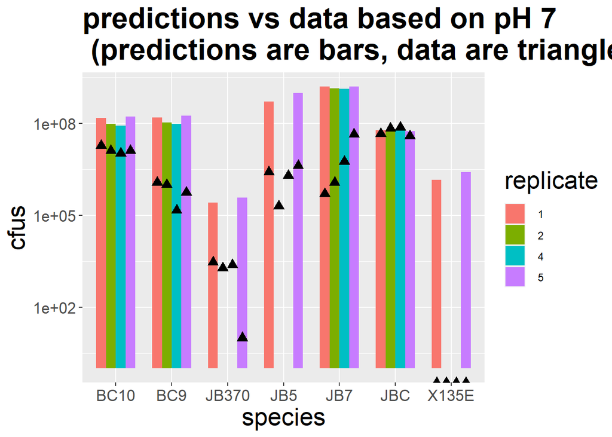

```r
dat.pred.long$replicate = as.character(dat.pred.long$replicate)
dat.pred.long = dat.pred.long %>%
  filter(replicate != "3")

dat.pred.long.pois$replicate = as.character(dat.pred.long.pois$replicate)
dat.pred.long.pois = dat.pred.long.pois %>%
  filter(replicate != "3")


dat.com.long = dat.com %>%
  pivot_longer(cols = !matches("rep"),
               names_to = "spec") %>%
  rename(fit = value) %>%
  filter(rep != 3)

write.csv(dat.com.long, here("4_res","community-data-long.csv"), row.names=F)


ggplot(data = dat.pred.long, aes(x = spec, y = fit))+
  geom_col(aes(fill=replicate),
           position = position_dodge(.7),
           width=.7)+
  geom_point(data = dat.com.long, shape=17,
             position = position_dodge(.7),
             aes(group = rep),
             size=3)+
  xlab("species")+
  ylab("cfus")+
  ggtitle("predictions vs data based on pH 7\n (predictions are bars, data are triangles)")+
  theme.mine+
  scale_y_log10()
```

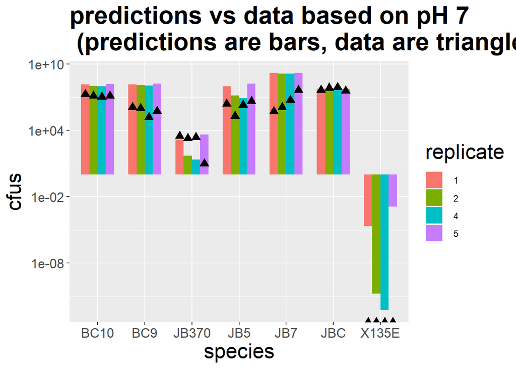

```r
ggplot(data = dat.pred.long.pois, aes(x = spec, y = fit))+
  geom_col(aes(fill=replicate),
           position = position_dodge(.7),
           width=.7)+
  geom_point(data = dat.com.long, shape=17,
             position = position_dodge(.7),
             aes(group = rep),
             size=3)+
  xlab("species")+
  ylab("cfus")+
  ggtitle("predictions vs data based on pH 7\n (predictions are bars, data are triangles)")+
  theme.mine+
  scale_y_log10()
```

# Comparing fits

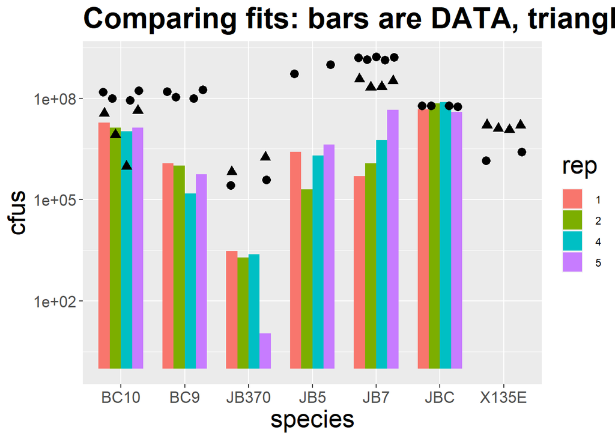

```r
dat.pred.5=read.csv(here("4_res","predictions-from-pH5.csv"))
dat.pred.7=read.csv(here("4_res","predictions-from-pH7.csv"))


dat.com.long$rep = as.character(dat.com.long$rep)
dat.com.long = dat.com.long %>%
  filter(rep != "3")

## account for zeros on log scale
dat.com.long$fit=dat.com.long$fit+1
dat.pred.5$fit = dat.pred.5$fit+1
dat.pred.7$fit = dat.pred.7$fit+1

ggplot(data = dat.com.long, aes(x = spec, y = fit))+
  geom_col(aes(fill=rep),
           position = position_dodge(.7),
           width=.7)+
  geom_point(data = dat.pred.5, shape=17,
             position = position_dodge(.7),
             aes(group = replicate),
             size=3)+
  geom_point(data = dat.pred.7, shape=21,
             position = position_dodge(.7),
             aes(group = replicate),
             size=3,
             fill="black")+
  xlab("species")+
  ylab("cfus")+
  ggtitle("Comparing fits: bars are DATA, triangles are pH 5 predictions, circles are ph 7.")+
  theme.mine+
  scale_y_log10()
```

```r
dat.pred.5$absfit=abs(dat.pred.5$fit)
dat.pred.5$fitcol="black"
dat.pred.5$fitcol[dat.pred.5$fit<0]="red"

dat.pred.7$absfit=abs(dat.pred.7$fit)
dat.pred.7$fitcol="black"
dat.pred.7$fitcol[dat.pred.7$fit<0]="red"

gfin = ggplot(data = dat.com.long, aes(x = spec, y = fit))+
  geom_col(aes(fill=rep),
           position = position_dodge(.7),
           width=.7)+
  geom_point(data = dat.pred.5, shape=17,
             position = position_dodge(.7),
             aes(y = absfit,
                 group = replicate),
             size=3,
             col=dat.pred.5$fitcol)+
  geom_point(data = dat.pred.7, shape=20,
             position = position_dodge(.7),
             aes(y = absfit,
                 group = replicate),
             size=5,
             col=dat.pred.7$fitcol)+
  xlab("species")+
  ylab("cfus")+
  ggtitle("")+
  theme.mine+
  ggtitle("Comparing fits: bars are DATA, triangles are pH 5 predictions, circles are ph 7.\n Predictions are shown by absolute value - red points are negative values")+
  scale_y_log10()

gfig_saver(gfig = gfin,
           filename = "comparing-ph-fits",
           description = "Plot of predictions of community dynamics from LV dynamics. Triangles are pH 5 predictions from single-species and pairwise competition experiments, circles from ph7. Bars are from the actual experiments.")
```

## Quantifying error

Quick check: MSE

```r
temp = dat.pred.5 %>%
  select(replicate, spec, fit) %>%
  rename(pred.5 = fit) %>%
  rename(rep = replicate)

temp2 = dat.pred.7 %>%
  select(replicate, spec, fit) %>%
  rename(pred.7 = fit)%>%
  rename(rep = replicate)

dat.comp = merge(temp, temp2)
dat.comp = merge(dat.comp, dat.com.long)
dat.comp
```

```
##    rep  spec        pred.5        pred.7      fit
## 1    1  BC10  3.518694e+07  1.521219e+08 19000001
## 2    1   BC9 -1.956164e+11  1.565593e+08  1200001
## 3    1 JB370  6.548889e+05  2.639314e+05     3001
## 4    1   JB5 -1.441726e+11  5.284238e+08  2600001
## 5    1   JB7  3.670954e+08  1.591308e+09   500001
## 6    1   JBC -5.140203e+09  6.065054e+07 46000001
## 7    1 X135E  1.606673e+07  1.432089e+06        1
## 8    2  BC10  8.178263e+06  9.931035e+07 13300001
## 9    2   BC9 -3.506386e+11  1.089558e+08  1000001
## 10   2 JB370 -2.441775e+06 -4.605027e+04     1921
## 11   2   JB5 -3.468497e+11 -1.120787e+09   200001
## 12   2   JB7  2.101527e+08  1.403430e+09  1200001
## 13   2   JBC -3.197835e+08  5.914285e+07 70000001
## 14   2 X135E  1.273653e+07 -2.497973e+06        1
## 15   4  BC10  9.560736e+05  8.643942e+07 10600001
## 16   4   BC9 -1.715133e+12  9.828415e+07   150001
## 17   4 JB370 -3.180641e+06 -1.184571e+05     2411
## 18   4   JB5 -1.677298e+12 -1.536426e+09  2000001
## 19   4   JB7  2.182106e+08  1.352077e+09  5800001
## 20   4   JBC -3.851376e+09  5.967883e+07 76000001
## 21   4 X135E  1.164955e+07 -3.494566e+06        1
## 22   5  BC10  4.267297e+07  1.691850e+08 13300001
## 23   5   BC9 -1.302853e+13  1.789951e+08   560001
## 24   5 JB370  1.814615e+06  3.817134e+05       11
## 25   5   JB5 -1.295634e+13  9.876688e+08  4300001
## 26   5   JB7  3.221490e+08  1.627733e+09 44800001
## 27   5   JBC -7.851529e+09  5.632032e+07 39000001
## 28   5 X135E  1.591610e+07  2.579161e+06        1
```

```r
#MSE for ph 5:
mse.ph5 = mean((dat.comp$fit-dat.comp$pred.5)^2)
#MSE for ph 7:
mse.ph7 = mean((dat.comp$fit-dat.comp$pred.7)^2)

mse.ph5/mse.ph7
```

```
## [1] 24875831
```

# Which interactions change

This is attempt 2, which is excluding the interaction terms for species which are at 0 density in pH 5

```r
dat.7 = read.csv(here("2_data_wrangling",
                      "matrix-form-pH7.csv"))
dat.5 = read.csv(here("2_data_wrangling",
                      "matrix-form.csv"))
dat.full = rbind(dat.7, dat.5)
dat.full$pH=as.character(dat.full$pH)
```

```r
findings = list()
sigfind = NULL
```

## BC9

```r
dat.cur = dat.full[dat.full$pres.BC9==1,]
out = lm(BC9 ~ BC10*pH + JB5*pH + JB7 + X135E*pH + JBC*pH + JB370*pH,
         data = dat.cur)
summary(out)
```

```
##
## Call:
## lm(formula = BC9 ~ BC10 * pH + JB5 * pH + JB7 + X135E * pH +
##     JBC * pH + JB370 * pH, data = dat.cur)
##
## Residuals:
##        Min         1Q     Median         3Q        Max
## -304110573  -28923023  -10062481   46280718  315530032
##
## Coefficients:
##               Estimate Std. Error t value Pr(>|t|)
## (Intercept)  4.249e+07  3.343e+07   1.271  0.20935
## BC10        -1.793e-01  4.843e-01  -0.370  0.71262
## pH7          2.341e+08  4.837e+07   4.840 1.16e-05 ***
## JB5         -1.472e+04  5.443e+04  -0.271  0.78782
## JB7          2.835e-02  2.351e-02   1.206  0.23327
## X135E        4.365e+00  1.497e+00   2.916  0.00518 **
## JBC         -4.125e-01  9.250e-01  -0.446  0.65749
## JB370        2.507e+01  4.494e+00   5.579 8.39e-07 ***
## BC10:pH7    -7.617e-01  5.413e-01  -1.407  0.16521
## pH7:JB5      1.472e+04  5.443e+04   0.271  0.78782
## pH7:X135E   -3.698e+00  3.143e+00  -1.177  0.24461
## pH7:JBC     -1.801e+00  1.663e+00  -1.083  0.28378
## pH7:JB370   -1.358e+02  8.151e+01  -1.667  0.10147
## ---
## Signif. codes:  0 '***' 0.001 '**' 0.01 '*' 0.05 '.' 0.1 ' ' 1
##
## Residual standard error: 108100000 on 53 degrees of freedom
## Multiple R-squared:  0.6425, Adjusted R-squared:  0.5616
## F-statistic: 7.939 on 12 and 53 DF,  p-value: 3.258e-08
```

```r
temp = Anova(out)
temp = temp[grep(':',rownames(temp)),]
temp = temp[temp$`Pr(>F)`<.1,]
findings$BC9 = list(all = Anova(out),
                    sigint = temp,
                    meta = "Insufficient variation in JB7 at pH5. Excluding JB7:pH")
#no terms mattered
```

## BC10

```r
dat.cur = dat.full[dat.full$pres.BC10==1,]
out = lm(BC10 ~ BC9*pH + JB5*pH + JB7*pH + X135E*pH + JBC*pH + JB370*pH,
         data = dat.cur)
summary(out)
```

```
##
## Call:
## lm(formula = BC10 ~ BC9 * pH + JB5 * pH + JB7 * pH + X135E *
##     pH + JBC * pH + JB370 * pH, data = dat.cur)
##
## Residuals:
##        Min         1Q     Median         3Q        Max
## -132388910  -44471680   -7298838   12969637  196274416
##
## Coefficients:
##               Estimate Std. Error t value Pr(>|t|)
## (Intercept)  8.591e+07  2.865e+07   2.999  0.00424 **
## BC9          6.087e-01  1.498e+00   0.407  0.68614
## pH7          1.691e+08  3.987e+07   4.241 9.84e-05 ***
## JB5         -4.004e-03  1.848e-02  -0.217  0.82941
## JB7          2.403e-03  3.473e-02   0.069  0.94511
## X135E        4.502e-01  1.326e+00   0.339  0.73570
## JBC         -1.120e+00  8.822e-01  -1.269  0.21032
## JB370        2.098e+01  7.064e+00   2.970  0.00460 **
## BC9:pH7     -1.088e+00  1.816e+00  -0.599  0.55207
## pH7:JB5      6.773e-03  2.215e-02   0.306  0.76109
## pH7:JB7      1.440e-02  3.882e-02   0.371  0.71218
## pH7:X135E   -1.999e+00  3.100e+00  -0.645  0.52202
## pH7:JBC     -1.093e+00  1.173e+00  -0.932  0.35600
## pH7:JB370   -1.948e+02  7.980e+01  -2.442  0.01828 *
## ---
## Signif. codes:  0 '***' 0.001 '**' 0.01 '*' 0.05 '.' 0.1 ' ' 1
##
## Residual standard error: 83150000 on 49 degrees of freedom
## Multiple R-squared:  0.5794, Adjusted R-squared:  0.4678
## F-statistic: 5.193 on 13 and 49 DF,  p-value: 1.064e-05
```

```r
temp = Anova(out)
temp = temp[grep(':',rownames(temp)),]
temp = temp[temp$`Pr(>F)`<.1,]
findings$BC10 = list(all = Anova(out),
                     sigint = temp,
                     meta = "All terms included")
#adding to overall data frame
sigfind.cur =as.data.frame(temp)
sigfind.cur$source.species = gsub(":","",
                                  gsub("pH","",rownames(sigfind.cur)))
sigfind.cur$target.species = "BC10"
sigfind = rbind(sigfind, sigfind.cur)
```

## JB5

```r
dat.cur = dat.full[dat.full$pres.JB5==1,]
out = lm(JB5 ~ BC9*pH + BC10*pH + JB7*pH + X135E*pH + JBC*pH + JB370*pH,
         data = dat.cur)
summary(out)
```

```
##
## Call:
## lm(formula = JB5 ~ BC9 * pH + BC10 * pH + JB7 * pH + X135E *
##     pH + JBC * pH + JB370 * pH, data = dat.cur)
##
## Residuals:
##        Min         1Q     Median         3Q        Max
## -1.791e+09 -3.570e+08 -3.262e+07  4.426e+08  2.520e+09
##
## Coefficients:
##               Estimate Std. Error t value Pr(>|t|)
## (Intercept)  3.571e+08  3.424e+08   1.043 0.302058
## BC9         -1.050e+01  1.939e+01  -0.542 0.590509
## pH7          3.368e+09  5.259e+08   6.404 5.13e-08 ***
## BC10         1.774e+01  6.679e+00   2.656 0.010571 *
## JB7         -2.892e+05  6.914e+05  -0.418 0.677518
## X135E        9.282e+01  3.801e+01   2.442 0.018187 *
## JBC         -5.391e+00  9.475e+00  -0.569 0.571948
## JB370       -2.905e+01  6.625e+01  -0.438 0.662978
## BC9:pH7      8.380e+00  1.948e+01   0.430 0.668874
## pH7:BC10    -1.837e+01  7.073e+00  -2.597 0.012326 *
## pH7:JB7      2.892e+05  6.914e+05   0.418 0.677518
## pH7:X135E   -1.156e+02  6.516e+01  -1.774 0.082171 .
## pH7:JBC     -6.359e+01  1.565e+01  -4.063 0.000171 ***
## pH7:JB370   -2.781e+03  5.883e+02  -4.728 1.89e-05 ***
## ---
## Signif. codes:  0 '***' 0.001 '**' 0.01 '*' 0.05 '.' 0.1 ' ' 1
##
## Residual standard error: 1.036e+09 on 50 degrees of freedom
## Multiple R-squared:  0.7172, Adjusted R-squared:  0.6436
## F-statistic: 9.753 on 13 and 50 DF,  p-value: 1.119e-09
```

```r
temp = Anova(out)
temp = temp[grep(':',rownames(temp)),]
temp = temp[temp$`Pr(>F)`<.1,]
findings$JB5 = list(all = Anova(out),
                    sigint = temp,
                    meta = "All terms included")
#adding to overall data frame
sigfind.cur =as.data.frame(temp)
sigfind.cur$source.species = gsub(":","",
                                  gsub("pH","",rownames(sigfind.cur)))
sigfind.cur$target.species = "JB5"
sigfind = rbind(sigfind, sigfind.cur)
```

## JB7

```r
dat.cur = dat.full[dat.full$pres.JB7==1,]
out = lm(JB7 ~ BC9*pH + BC10*pH + JB5*pH + X135E*pH + JBC*pH + JB370*pH,
         data = dat.cur)
summary(out)
```

```
##
## Call:
## lm(formula = JB7 ~ BC9 * pH + BC10 * pH + JB5 * pH + X135E *
##     pH + JBC * pH + JB370 * pH, data = dat.cur)
##
## Residuals:
##        Min         1Q     Median         3Q        Max
## -1.419e+09 -1.352e+08  1.224e+07  1.857e+08  9.974e+08
##
## Coefficients:
##               Estimate Std. Error t value Pr(>|t|)
## (Intercept) -2.063e+07  1.278e+08  -0.161    0.872
## BC9          7.267e-01  1.015e+01   0.072    0.943
## pH7          1.897e+09  2.081e+08   9.118 2.28e-12 ***
## BC10         1.611e+01  2.741e+00   5.877 3.01e-07 ***
## JB5          2.850e+01  4.344e+02   0.066    0.948
## X135E        1.481e+02  1.271e+01  11.658 4.00e-16 ***
## JBC          1.435e-01  1.364e+00   0.105    0.917
## JB370        3.332e+01  2.893e+01   1.151    0.255
## BC9:pH7      5.426e-01  1.017e+01   0.053    0.958
## pH7:BC10    -1.363e+01  2.856e+00  -4.771 1.52e-05 ***
## pH7:JB5     -2.851e+01  4.344e+02  -0.066    0.948
## pH7:X135E    4.319e+01  2.309e+01   1.871    0.067 .
## pH7:JBC     -7.384e+00  5.676e+00  -1.301    0.199
## pH7:JB370   -2.699e+02  1.959e+02  -1.378    0.174
## ---
## Signif. codes:  0 '***' 0.001 '**' 0.01 '*' 0.05 '.' 0.1 ' ' 1
##
## Residual standard error: 4.21e+08 on 52 degrees of freedom
## Multiple R-squared:  0.921,  Adjusted R-squared:  0.9012
## F-statistic: 46.62 on 13 and 52 DF,  p-value: < 2.2e-16
```

```r
temp = Anova(out)
temp = temp[grep(':',rownames(temp)),]
temp = temp[temp$`Pr(>F)`<.1,]
findings$JB7 = list(all = Anova(out),
                    sigint = temp,
                    meta = "All terms included")
#adding to overall data frame
sigfind.cur =as.data.frame(temp)
sigfind.cur$source.species = gsub(":","",
                                  gsub("pH","",rownames(sigfind.cur)))
sigfind.cur$target.species = "JB7"
sigfind = rbind(sigfind, sigfind.cur)
```

## X135E

```r
dat.cur = dat.full[dat.full$pres.X135E==1,]
out = lm(X135E ~ BC9*pH + BC10*pH + JB5*pH + JB7*pH + JBC*pH + JB370*pH,
         data = dat.cur)
summary(out)
```

```
##
## Call:
## lm(formula = X135E ~ BC9 * pH + BC10 * pH + JB5 * pH + JB7 *
##     pH + JBC * pH + JB370 * pH, data = dat.cur)
##
## Residuals:
##       Min        1Q    Median        3Q       Max
## -16323810  -4004118   -486141   4122702  26253884
##
## Coefficients:
##               Estimate Std. Error t value Pr(>|t|)
## (Intercept)  1.798e+07  2.490e+06   7.221  2.2e-09 ***
## BC9          8.187e-02  1.956e-02   4.186 0.000110 ***
## pH7         -9.148e+06  3.978e+06  -2.299 0.025524 *
## BC10         1.455e-01  3.900e-02   3.731 0.000474 ***
## JB5         -1.207e-03  2.155e-03  -0.560 0.577895
## JB7          8.471e-05  1.691e-03   0.050 0.960239
## JBC         -1.037e-01  3.813e-02  -2.719 0.008868 **
## JB370       -1.186e+00  1.176e+00  -1.009 0.317683
## BC9:pH7     -6.147e-02  2.558e-02  -2.403 0.019851 *
## pH7:BC10    -1.424e-01  4.212e-02  -3.382 0.001374 **
## pH7:JB5      1.745e-03  2.529e-03   0.690 0.493304
## pH7:JB7      8.276e-04  2.032e-03   0.407 0.685467
## pH7:JBC     -5.908e-02  1.008e-01  -0.586 0.560282
## pH7:JB370    2.257e+00  3.102e+00   0.728 0.470127
## ---
## Signif. codes:  0 '***' 0.001 '**' 0.01 '*' 0.05 '.' 0.1 ' ' 1
##
## Residual standard error: 8739000 on 52 degrees of freedom
## Multiple R-squared:  0.6103, Adjusted R-squared:  0.5129
## F-statistic: 6.265 on 13 and 52 DF,  p-value: 6.891e-07
```

```r
temp = Anova(out)
temp = temp[grep(':',rownames(temp)),]
temp = temp[temp$`Pr(>F)`<.1,]
findings$X135E = list(all = Anova(out),
                      sigint = temp,
                      meta = "All terms included")
#adding to overall data frame
sigfind.cur =as.data.frame(temp)
sigfind.cur$source.species = gsub(":","",
                                  gsub("pH","",rownames(sigfind.cur)))
sigfind.cur$target.species = "X135E"
sigfind = rbind(sigfind, sigfind.cur)
```

## JBC

```r
dat.cur = dat.full[dat.full$pres.JBC==1,]
# View(dat.cur)
out = lm(JBC ~ BC9*pH + BC10*pH + JB5 + JB7*pH + X135E + JB370*pH,
         data = dat.cur)
summary(out)
```

```
##
## Call:
## lm(formula = JBC ~ BC9 * pH + BC10 * pH + JB5 + JB7 * pH + X135E +
##     JB370 * pH, data = dat.cur)
##
## Residuals:
##       Min        1Q    Median        3Q       Max
## -33439899 -10404664  -1617057   3930022 166560101
##
## Coefficients:
##               Estimate Std. Error t value Pr(>|t|)
## (Intercept)  6.944e+07  6.214e+06  11.174 2.56e-15 ***
## BC9          8.469e-03  6.166e-01   0.014   0.9891
## pH7         -1.309e+07  9.863e+06  -1.327   0.1905
## BC10        -5.559e-01  6.349e-01  -0.876   0.3854
## JB5         -1.739e-02  1.972e-01  -0.088   0.9301
## JB7          1.558e+01  1.814e+00   8.590 1.76e-11 ***
## X135E       -5.312e+04  2.734e+04  -1.943   0.0576 .
## JB370       -3.047e+01  2.899e+01  -1.051   0.2982
## BC9:pH7     -5.867e-02  6.212e-01  -0.094   0.9251
## pH7:BC10     5.839e-01  6.461e-01   0.904   0.3704
## pH7:JB7     -1.559e+01  1.814e+00  -8.594 1.74e-11 ***
## pH7:JB370    1.322e+03  9.200e+03   0.144   0.8863
## ---
## Signif. codes:  0 '***' 0.001 '**' 0.01 '*' 0.05 '.' 0.1 ' ' 1
##
## Residual standard error: 28320000 on 51 degrees of freedom
## Multiple R-squared:  0.6427, Adjusted R-squared:  0.5657
## F-statistic: 8.341 on 11 and 51 DF,  p-value: 3.871e-08
```

```r
temp = Anova(out)
temp = temp[grep(':',rownames(temp)),]
temp = temp[temp$`Pr(>F)`<.1,]
findings$JBC = list(all = Anova(out),
                    sigint = temp,
                    meta = "Insufficient JB5 and X135E at pH 5 - both JB5:pH and X135E:pH were removed.")
#adding to overall data frame
sigfind.cur = as.data.frame(temp)
sigfind.cur$source.species = gsub(":","",
                                  gsub("pH","",rownames(sigfind.cur)))
sigfind.cur$target.species = "JBC"
sigfind = rbind(sigfind, sigfind.cur)
```

## JB370

```r
dat.cur = dat.full[dat.full$pres.JB370==1,]
out = lm(JB370 ~ BC9*pH + BC10*pH + JB5*pH + JB7*pH + X135E*pH + JBC*pH,
         data = dat.cur)
summary(out)
```

```
##
## Call:
## lm(formula = JB370 ~ BC9 * pH + BC10 * pH + JB5 * pH + JB7 *
##     pH + X135E * pH + JBC * pH, data = dat.cur)
##
## Residuals:
##      Min       1Q   Median       3Q      Max
## -7353045  -458549   -53831   350771  8759462
##
## Coefficients:
##               Estimate Std. Error t value Pr(>|t|)
## (Intercept)  6.451e+06  7.697e+05   8.381 5.03e-11 ***
## BC9          1.445e-02  3.350e-03   4.314 7.75e-05 ***
## pH7         -5.540e+06  1.092e+06  -5.073 6.02e-06 ***
## BC10         1.833e-03  6.383e-03   0.287 0.775224
## JB5          9.279e-03  1.080e-02   0.859 0.394605
## JB7          6.086e-03  4.419e-03   1.377 0.174671
## X135E       -1.973e-01  1.127e-01  -1.751 0.086156 .
## JBC         -1.277e-01  3.524e-02  -3.624 0.000688 ***
## BC9:pH7     -1.587e-02  6.234e-03  -2.546 0.014081 *
## pH7:BC10    -3.557e-03  1.000e-02  -0.356 0.723725
## pH7:JB5     -9.108e-03  1.094e-02  -0.833 0.409072
## pH7:JB7     -5.782e-03  4.527e-03  -1.277 0.207534
## pH7:X135E    3.098e-01  1.837e-01   1.686 0.098152 .
## pH7:JBC      1.144e-01  4.240e-02   2.698 0.009538 **
## ---
## Signif. codes:  0 '***' 0.001 '**' 0.01 '*' 0.05 '.' 0.1 ' ' 1
##
## Residual standard error: 2605000 on 49 degrees of freedom
## Multiple R-squared:  0.7168, Adjusted R-squared:  0.6417
## F-statistic: 9.541 on 13 and 49 DF,  p-value: 1.963e-09
```

```r
temp = Anova(out)
temp = temp[grep(':',rownames(temp)),]
temp = temp[temp$`Pr(>F)`<.1,]
findings$JB370 = list(all = Anova(out),
                      sigint = temp,
                      meta = "All terms included")
#adding to overall data frame
sigfind.cur =as.data.frame(temp)
sigfind.cur$source.species = gsub(":","",
                                  gsub("pH","",rownames(sigfind.cur)))
sigfind.cur$target.species = "JB370"
sigfind = rbind(sigfind, sigfind.cur)
```

## Saving

```r
write.csv(sigfind,here("4_res","pH-interaction-estimates.csv"))

saveRDS(findings, file = here("4_res","ph-interactions-list-obj.RDS"))
```